# Comparative Gut Microbiome Diversity and Taxonomic Profiling in Inflammatory Bowel Disease

2026-11-17

# 1 Project Overview and Environment Setup

This project investigates gut microbiome community structure and taxonomic alterations in Inflammatory Bowel Disease (IBD) compared to non-IBD controls using public 16S rRNA sequencing data from the integrative Human Microbiome Project (iHMP / HMP2), accessed via the Bioconductor package `HMP2Data` (Stansfield et al., 2024).

The workflow integrates analytical techniques from: - **IT4133 Bioinformatics and Computational Biology:** Community diversity, Bray-Curtis dissimilarity, UPGMA hierarchical clustering, pattern recognition, and negative binomial differential expression modeling. - **EL4152 Machine Learning:** Supervised and unsupervised learning, $k$-means clustering, Support Vector Machines (Linear and Radial), Random Forest ensembles, rigorous data leakage prevention, cross-validation, and classification performance evaluation under the curse of dimensionality.

## 1.1 Library Loading

```r
# Configure library paths
.libPaths(c("C:/Users/User/AppData/Local/R/win-library/4.6", .libPaths()))

# Core packages
library(here)
library(HMP2Data)
library(phyloseq)
library(tidyverse)
library(vegan)
library(cluster)
library(mclust)
library(ape)
library(DESeq2)
library(caret)
library(randomForest)
library(pROC)
library(e1071)
library(kernlab)
library(pheatmap)

# Global seed for stochastic reproducibility
set.seed(42)

# Ensure figures output directory exists using relative paths
fig_dir <- here::here("figures")
dir.create(fig_dir, showWarnings = FALSE, recursive = TRUE)
```

# 2 Phase 0 & 1: Data Import, Inspection, and Preprocessing

## 2.1 Data Loading and Initial Inspection

The primary data object is retrieved programmatically via `HMP2Data::IBD16S()`.

```r
# Retrieve the IBD 16S phyloseq object
ps_raw <- HMP2Data::IBD16S()

cat("Raw dataset dimensions:\n")
```

```
## Raw dataset dimensions:
```

```r
cat("Total samples:", nsamples(ps_raw), "\n")
```

```
## Total samples: 178
```

```r
cat("Total taxa:", ntaxa(ps_raw), "\n")
```

```
## Total taxa: 982
```

```r
cat("Taxonomic ranks:", paste(rank_names(ps_raw), collapse = " > "), "\n")
```

```
## Taxonomic ranks: Kingdom > Phylum > Class > Order > Family > Genus
```

```r
cat("Taxa are rows:", taxa_are_rows(ps_raw), "\n")
```

```
## Taxa are rows: TRUE
```

```r
# Extract metadata as a standard data frame
meta_raw <- as(sample_data(ps_raw), "data.frame")
cat("Total unique participants (subject_id):", length(unique(meta_raw$subject_id)), "\n")
```

```
## Total unique participants (subject_id): 81
```

```r
cat("Raw diagnosis distribution:\n")
```

```
## Raw diagnosis distribution:
```

```r
print(table(meta_raw$diagnosis, useNA = "ifany"))
```

```
##
##     CD nonIBD     UC
##     86     46     46
```

## 2.2 Quality Control and Sample Deduplication

In clinical microbiome studies with longitudinal sampling, repeated measures from the same patient violate the assumption of independent observations required by standard statistical hypothesis tests (such as the Wilcoxon rank-sum test and PERMANOVA). To ensure statistical independence: 1. Only the earliest recorded sample per participant is retained by deterministically sorting by participant ID, visit number, and week number before deduplication. 2. Samples with sequencing depth below 1,000 reads are excluded to avoid unstable richness estimates. 3. A binary group factor is constructed (`Control` vs `IBD`, where CD and UC are merged into `IBD`).

```r
# Sort deterministically by participant and longitudinal visit order
ord <- order(meta_raw$subject_id, meta_raw$visit_number, meta_raw$week_num)
meta_sorted <- meta_raw[ord, ]

# Identify the earliest sample per subject
first_samples <- rownames(meta_sorted)[!duplicated(meta_sorted$subject_id)]
ps_one <- prune_samples(first_samples, ps_raw)
cat("Samples after retaining one baseline sample per subject:", nsamples(ps_one), "\n")
```

```
## Samples after retaining one baseline sample per subject: 81
```

```r
# Sequencing depth filtering: retain samples with >= 1,000 reads
depths <- sample_sums(ps_one)
cat("Minimum library depth before filtering:", min(depths), "reads\n")
```

```
## Minimum library depth before filtering: 42 reads
```

```r
cat("Maximum library depth before filtering:", max(depths), "reads\n")
```

```
## Maximum library depth before filtering: 30151 reads
```

```r
cat("Samples with depth < 1,000 reads:", sum(depths < 1000), "\n")
```

```
## Samples with depth < 1,000 reads: 10
```

```r
keep_samples <- names(depths)[depths >= 1000]
ps_depth <- prune_samples(keep_samples, ps_one)
cat("Samples retained after depth filtering (>= 1,000 reads):", nsamples(ps_depth), "\n")
```

```
## Samples retained after depth filtering (>= 1,000 reads): 71
```

```r
# Construct diagnosis factors
sample_data(ps_depth)$dx3 <- factor(sample_data(ps_depth)$diagnosis, levels = c("CD", "UC", "nonIBD"))
sample_data(ps_depth)$group <- factor(
  ifelse(sample_data(ps_depth)$dx3 == "nonIBD", "Control", "IBD"),
  levels = c("Control", "IBD")
)

# Export cohort summary table
cohort_summary <- as.data.frame(table(
  Group = sample_data(ps_depth)$group,
  Diagnosis = sample_data(ps_depth)$dx3
))
write.csv(cohort_summary, file.path(fig_dir, "cohort_summary.csv"), row.names = FALSE)

cat("Cohort breakdown after quality control:\n")
```

```
## Cohort breakdown after quality control:
```

```r
print(cohort_summary)
```

```
##     Group Diagnosis Freq
## 1 Control        CD    0
## 2     IBD        CD   31
## 3 Control        UC    0
## 4     IBD        UC   18
## 5 Control    nonIBD   22
## 6     IBD    nonIBD    0
```

## 2.3 Taxonomic Prevalence Filtering for Ecological Analyses

Low-prevalence taxa (present in fewer than 10% of samples) represent sequencing noise and inflate the penalty of multiple testing. For exploratory diversity and community clustering analyses, taxa present in at least 10% of the filtered samples are retained.

```r
otu_mat <- as(otu_table(ps_depth), "matrix")
if (!taxa_are_rows(ps_depth)) otu_mat <- t(otu_mat)

# Calculate prevalence across samples
taxa_prev <- rowSums(otu_mat > 0)
prevalence_threshold <- 0.10 * nsamples(ps_depth)
keep_taxa_eco <- names(taxa_prev)[taxa_prev >= prevalence_threshold]

ps_filt <- prune_taxa(keep_taxa_eco, ps_depth)
cat("Taxa retained (>= 10% prevalence):", ntaxa(ps_filt), "out of", ntaxa(ps_depth), "\n")
```

```
## Taxa retained (>= 10% prevalence): 201 out of 982
```

# 3 Phase 2: Alpha Diversity Analysis

Within-sample alpha diversity is assessed using Shannon entropy (sensitive to both richness and evenness) and the Gini-Simpson index (weighted toward dominant species). Because alpha diversity indices are sensitive to variation in sequencing depth, library sizes are rarefied to uniform sampling depth prior to metric computation (McMurdie and Holmes, 2014).

Between-group differences are tested using two-tailed Wilcoxon rank-sum tests (Mann-Whitney U), as diversity indices frequently deviate from normality.

```r
# Rarefy to minimum observed sequencing depth
min_seq_depth <- min(sample_sums(ps_depth))
cat("Rarefying to uniform depth:", min_seq_depth, "reads\n")
```

```
## Rarefying to uniform depth: 1415 reads
```

```r
ps_rarefied <- phyloseq::rarefy_even_depth(
  ps_depth,
  sample.size = min_seq_depth,
  rngseed = 42,
  verbose = FALSE
)

# Calculate alpha diversity indices
alpha_metrics <- phyloseq::estimate_richness(ps_rarefied, measures = c("Shannon", "Simpson"))
alpha_metrics$group <- sample_data(ps_rarefied)$group
alpha_metrics$sample_id <- rownames(alpha_metrics)

# Statistical hypothesis testing (Wilcoxon rank-sum test)
w_shannon <- wilcox.test(Shannon ~ group, data = alpha_metrics)
w_simpson <- wilcox.test(Simpson ~ group, data = alpha_metrics)

shannon_ctrl_med <- median(alpha_metrics$Shannon[alpha_metrics$group == "Control"])
shannon_ibd_med  <- median(alpha_metrics$Shannon[alpha_metrics$group == "IBD"])
simpson_ctrl_med <- median(alpha_metrics$Simpson[alpha_metrics$group == "Control"])
simpson_ibd_med  <- median(alpha_metrics$Simpson[alpha_metrics$group == "IBD"])

cat("Alpha Diversity Statistics:\n")
```

```
## Alpha Diversity Statistics:
```

```r
cat("Shannon Index: Control Median =", round(shannon_ctrl_med, 3),
    "; IBD Median =", round(shannon_ibd_med, 3),
    "; W =", w_shannon$statistic, "; p-value =", round(w_shannon$p.value, 4), "\n")
```

```
## Shannon Index: Control Median = 2.873 ; IBD Median = 2.581 ; W = 628 ; p-value = 0.2734
```

```r
cat("Simpson Index: Control Median =", round(simpson_ctrl_med, 3),
    "; IBD Median =", round(simpson_ibd_med, 3),
    "; W =", w_simpson$statistic, "; p-value =", round(w_simpson$p.value, 4), "\n")
```

```
## Simpson Index: Control Median = 0.884 ; IBD Median = 0.856 ; W = 616 ; p-value = 0.3442
```

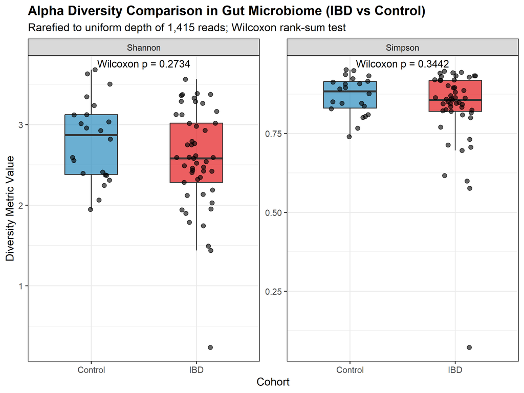

```r
# Visualization: Alpha diversity boxplots with jitter
alpha_long <- alpha_metrics %>%
  pivot_longer(cols = c("Shannon", "Simpson"), names_to = "Metric", values_to = "Diversity") %>%
  mutate(p_label = ifelse(Metric == "Shannon",
                          paste0("Wilcoxon p = ", round(w_shannon$p.value, 4)),
                          paste0("Wilcoxon p = ", round(w_simpson$p.value, 4))))

p_alpha <- ggplot(alpha_long, aes(x = group, y = Diversity, fill = group)) +
  geom_boxplot(outlier.shape = NA, alpha = 0.7, width = 0.5) +
  geom_jitter(width = 0.2, alpha = 0.6, size = 2) +
  facet_wrap(~ Metric, scales = "free_y") +
  scale_fill_manual(values = c("Control" = "#2b8cbe", "IBD" = "#e41a1c")) +
  geom_text(aes(x = 1.5, y = Inf, label = p_label), vjust = 1.5, check_overlap = TRUE, size = 4) +
  labs(
    title = "Alpha Diversity Comparison in Gut Microbiome (IBD vs Control)",
    subtitle = "Rarefied to uniform depth of 1,415 reads; Wilcoxon rank-sum test",
    x = "Cohort",
    y = "Diversity Metric Value"
  ) +
  theme_bw(base_size = 12) +
  theme(legend.position = "none", plot.title = element_text(face = "bold"))

ggsave(file.path(fig_dir, "alpha.png"), p_alpha, width = 7, height = 5)
p_alpha
```

# 4 Phase 3: Beta Diversity and Community Structure

Beta diversity evaluates differences in community composition across samples. Counts are transformed to relative abundance, and pairwise Bray-Curtis dissimilarities (Bray and Curtis, 1957) are computed.

Group divergence is tested via Permutational Multivariate Analysis of Variance (PERMANOVA; `vegan::adonis2`, 999 permutations). Homogeneity of multivariate dispersion is verified using `vegan::betadisper` to distinguish true community centroid shifts from within-group variance differences (Anderson, 2001; Anderson, 2006). Non-metric multidimensional scaling (NMDS) is employed for two-dimensional ordination.

```r
# Transform filtered counts to relative abundance
ps_rel <- phyloseq::transform_sample_counts(ps_filt, function(x) x / sum(x))

# Compute pairwise Bray-Curtis distance matrix
bc_dist <- phyloseq::distance(ps_rel, method = "bray")

# Test homogeneity of multivariate dispersion
disp_model <- vegan::betadisper(bc_dist, sample_data(ps_rel)$group)
disp_test <- anova(disp_model)
cat("Multivariate Dispersion Test (betadisper):\n")
```

```
## Multivariate Dispersion Test (betadisper):
```

```r
cat("F =", round(disp_test$`F value`[1], 3), "; p-value =", round(disp_test$`Pr(>F)`[1], 4), "\n")
```

```
## F = 2.3 ; p-value = 0.134
```

```r
# PERMANOVA test
set.seed(42)
permanova_res <- vegan::adonis2(
  bc_dist ~ group,
  data = as(sample_data(ps_rel), "data.frame"),
  permutations = 999
)
cat("PERMANOVA Results (adonis2):\n")
```

```
## PERMANOVA Results (adonis2):
```

```r
print(permanova_res)
```

```
## Permutation test for adonis under reduced model
## Permutation: free
## Number of permutations: 999
##
## vegan::adonis2(formula = bc_dist ~ group, data = as(sample_data(ps_rel), "data.frame"), permutations = 999)
##          Df SumOfSqs      R2      F Pr(>F)
## Model     1   0.2957 0.01802 1.2659  0.199
## Residual 69  16.1158 0.98198
## Total    70  16.4115 1.00000
```

```r
# NMDS Ordination
set.seed(42)
nmds_res <- phyloseq::ordinate(ps_rel, method = "NMDS", distance = "bray", trymax = 50)
```

```
## *** Best solution repeated 3 times
```

```r
cat("NMDS 2D Stress Value:", round(nmds_res$stress, 4), "\n")
```

```
## NMDS 2D Stress Value: 0.1869
```

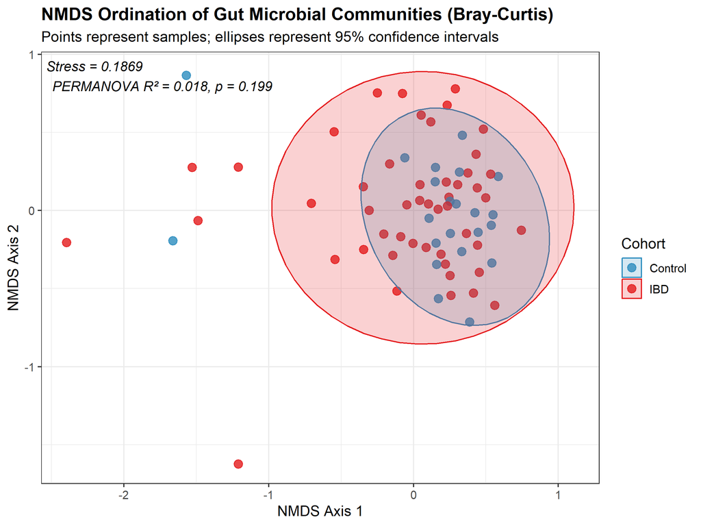

```r
# Plot NMDS ordination
nmds_points <- as.data.frame(nmds_res$points)
nmds_points$group <- sample_data(ps_rel)$group

p_nmds <- ggplot(nmds_points, aes(x = MDS1, y = MDS2, color = group, fill = group)) +
  geom_point(size = 3, alpha = 0.8) +
  stat_ellipse(geom = "polygon", alpha = 0.2, level = 0.95, type = "t") +
  scale_color_manual(values = c("Control" = "#2b8cbe", "IBD" = "#e41a1c")) +
  scale_fill_manual(values = c("Control" = "#2b8cbe", "IBD" = "#e41a1c")) +
  annotate("text", x = -Inf, y = Inf, hjust = -0.05, vjust = 1.3,
           label = paste0("Stress = ", round(nmds_res$stress, 4),
                          "\nPERMANOVA R² = ", round(permanova_res$R2[1], 4),
                          ", p = ", permanova_res$`Pr(>F)`[1]),
           size = 4, fontface = "italic") +
  labs(
    title = "NMDS Ordination of Gut Microbial Communities (Bray-Curtis)",
    subtitle = "Points represent samples; ellipses represent 95% confidence intervals",
    x = "NMDS Axis 1",
    y = "NMDS Axis 2",
    color = "Cohort",
    fill = "Cohort"
  ) +
  theme_bw(base_size = 12) +
  theme(plot.title = element_text(face = "bold"))

ggsave(file.path(fig_dir, "nmds.png"), p_nmds, width = 7, height = 5)
p_nmds
```

# 5 Phase 4: Unsupervised Learning (IT4133 & EL4152)

Unsupervised pattern recognition explores whether unlabeled microbial abundance profiles naturally partition into clusters corresponding to clinical status.

## 5.1 UPGMA Hierarchical Clustering

Unweighted Pair Group Method with Arithmetic Mean (UPGMA; Sokal and Michener, 1958) is performed using average-linkage hierarchical clustering (`hclust(..., method = "average")`) on Bray-Curtis dissimilarities. The cophenetic correlation coefficient is calculated to assess distance preservation.

```r
# UPGMA average-linkage clustering
hc_upgma <- hclust(bc_dist, method = "average")
coph_corr <- cor(cophenetic(hc_upgma), bc_dist)
cat("UPGMA Cophenetic Correlation Coefficient:", round(coph_corr, 4), "\n")
```

```
## UPGMA Cophenetic Correlation Coefficient: 0.8533
```

```r
# Convert to phylo object for tree plotting with ape
phylo_tree <- ape::as.phylo(hc_upgma)
tip_colors <- ifelse(sample_data(ps_rel)$group[match(phylo_tree$tip.label, sample_names(ps_rel))] == "Control",
                     "#2b8cbe", "#e41a1c")

png(file.path(fig_dir, "upgma_dendrogram.png"), width = 1200, height = 900, res = 150)
plot(phylo_tree, tip.color = tip_colors, cex = 0.6,
     main = paste0("UPGMA Hierarchical Clustering (Cophenetic r = ", round(coph_corr, 3), ")"))
legend("topleft", legend = c("Control", "IBD"), fill = c("#2b8cbe", "#e41a1c"), bty = "n", cex = 0.9)
dev.off()
```

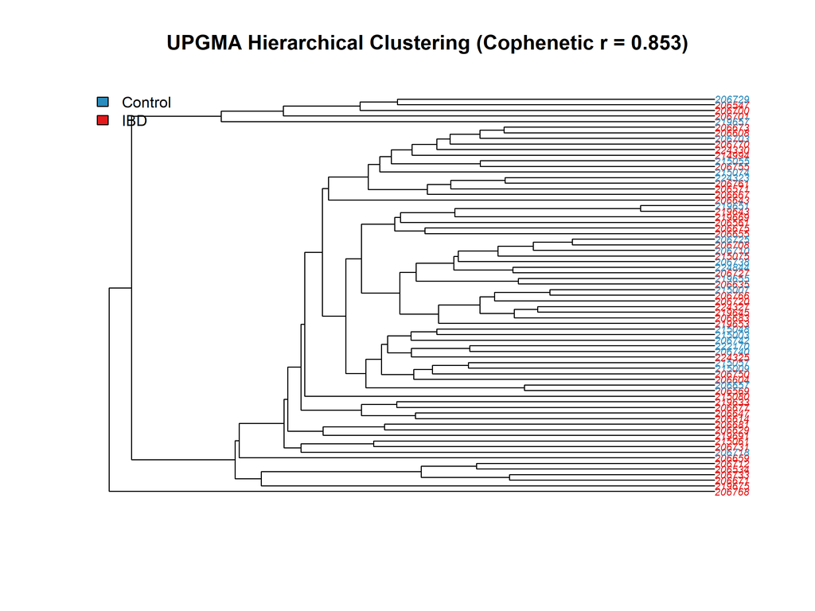

```r
# Display tree in notebook
plot(phylo_tree, tip.color = tip_colors, cex = 0.6,
     main = paste0("UPGMA Hierarchical Clustering (Cophenetic r = ", round(coph_corr, 3), ")"))
legend("topleft", legend = c("Control", "IBD"), fill = c("#2b8cbe", "#e41a1c"), bty = "n", cex = 0.9)
```

```r
# Cut tree at k = 2
upgma_clusters <- cutree(hc_upgma, k = 2)
upgma_tab <- table(Cluster = upgma_clusters, Group = sample_data(ps_rel)$group)
ari_upgma <- mclust::adjustedRandIndex(upgma_clusters, sample_data(ps_rel)$group)

cat("UPGMA (k = 2) Cluster vs Group Contingency Table:\n")
```

```
## UPGMA (k = 2) Cluster vs Group Contingency Table:
```

```r
print(upgma_tab)
```

```
##        Group
## Cluster Control IBD
##       1      22  48
##       2       0   1
```

```r
cat("UPGMA Adjusted Rand Index (ARI):", round(ari_upgma, 4), "\n")
```

```
## UPGMA Adjusted Rand Index (ARI): -0.0154
```

## 5.2 $k$-Means Clustering on PCoA Coordinates

$k$-means clustering operates in Euclidean space. Non-Euclidean Bray-Curtis dissimilarities are projected into Euclidean coordinate space via Principal Coordinates Analysis (PCoA; `cmdscale`, $k = 5$). Cluster validity across $k = 2$ to $k = 6$ is evaluated using average silhouette width (`cluster::silhouette`) to identify optimal cluster separation.

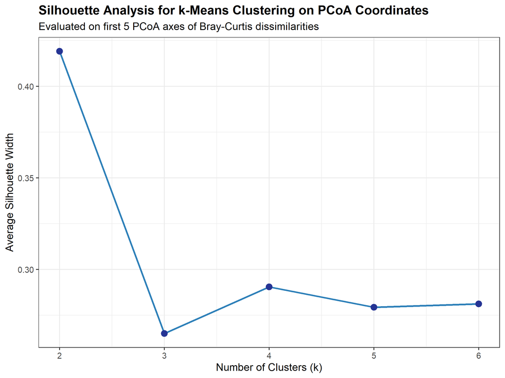

```r
# Classical multidimensional scaling (PCoA) to Euclidean space
pcoa_coords <- cmdscale(bc_dist, k = 5)

# Silhouette analysis across k = 2 to 6
k_range <- 2:6
sil_scores <- sapply(k_range, function(k) {
  set.seed(42)
  km <- kmeans(pcoa_coords, centers = k, nstart = 25)
  ss <- cluster::silhouette(km$cluster, dist(pcoa_coords))
  mean(ss[, "sil_width"])
})

sil_df <- data.frame(k = k_range, Silhouette = sil_scores)

p_sil <- ggplot(sil_df, aes(x = k, y = Silhouette)) +
  geom_line(color = "#2c7fb8", linewidth = 1) +
  geom_point(color = "#253494", size = 3) +
  scale_x_continuous(breaks = k_range) +
  labs(
    title = "Silhouette Analysis for k-Means Clustering on PCoA Coordinates",
    subtitle = "Evaluated on first 5 PCoA axes of Bray-Curtis dissimilarities",
    x = "Number of Clusters (k)",
    y = "Average Silhouette Width"
  ) +
  theme_bw(base_size = 12) +
  theme(plot.title = element_text(face = "bold"))

ggsave(file.path(fig_dir, "kmeans_silhouette.png"), p_sil, width = 7, height = 4.5)
p_sil
```

```r
# Fit k-means with k = 2
set.seed(42)
km_res <- kmeans(pcoa_coords, centers = 2, nstart = 25)
km_tab <- table(Cluster = km_res$cluster, Group = sample_data(ps_rel)$group)
ari_kmeans <- mclust::adjustedRandIndex(km_res$cluster, sample_data(ps_rel)$group)

cat("k-means (k = 2) Cluster vs Group Contingency Table:\n")
```

```
## k-means (k = 2) Cluster vs Group Contingency Table:
```

```r
print(km_tab)
```

```
##        Group
## Cluster Control IBD
##       1       2   5
##       2      20  44
```

```r
cat("k-means Adjusted Rand Index (ARI):", round(ari_kmeans, 4), "\n")
```

```
## k-means Adjusted Rand Index (ARI): -0.0112
```

### 5.2.1 Interpretation Guard

The low Adjusted Rand Index values observed in both UPGMA ($\text{ARI} = -0.0154$) and $k$-means ($\text{ARI} = -0.0112$) indicate that unsupervised clustering does not automatically recover the binary disease phenotype. This does not indicate that the microbiota lacks clinical relevance; rather, unsupervised methods capture dominant ecological gradients (such as enterotype variations, mucosal moisture, or dominant commensal community states) that can cut across clinical labels.

# 6 Phase 5: Differential Abundance Analysis (DESeq2)

Differential taxonomic abundance is evaluated using generalized linear models with negative binomial error distributions implemented in `DESeq2` (Love et al., 2014). Taxa are agglomerated to the Genus rank to ensure robust biological annotation. Raw unrarefied integer counts are modeled with a pseudocount (+1) to accommodate zeros, and size factors are estimated using the `poscounts` method tailored for sparse metagenomic census data.

```r
# Agglomerate taxa to Genus rank
ps_genus <- phyloseq::tax_glom(ps_depth, taxrank = "Genus", NArm = TRUE)
cat("Total agglomerated genera:", ntaxa(ps_genus), "\n")
```

```
## Total agglomerated genera: 476
```

```r
# Convert to DESeq2 dataset
dds <- phyloseq::phyloseq_to_deseq2(ps_genus, ~ group)

# Add pseudocount of 1 to count matrix
counts(dds) <- counts(dds) + 1L

# Estimate size factors via poscounts
dds <- DESeq2::estimateSizeFactors(dds, type = "poscounts")
dds <- DESeq2::DESeq(dds, test = "Wald", fitType = "local")

# Extract differential results (contrast: IBD vs Control)
res <- DESeq2::results(dds, contrast = c("group", "IBD", "Control"), alpha = 0.05)
res_df <- as.data.frame(res)

# Attach taxonomic classifications
tax_genus <- as.data.frame(as(tax_table(ps_genus), "matrix"))
res_df$Genus <- tax_genus[rownames(res_df), "Genus"]
res_df$Family <- tax_genus[rownames(res_df), "Family"]
res_df$Phylum <- tax_genus[rownames(res_df), "Phylum"]

# Classify significance status
res_df <- res_df %>%
  mutate(status = case_when(
    padj < 0.05 & log2FoldChange > 1.0 ~ "Enriched in IBD",
    padj < 0.05 & log2FoldChange < -1.0 ~ "Depleted in IBD",
    padj < 0.05 ~ "Significant (|log2FC| <= 1)",
    TRUE ~ "Not significant"
  ))

# Export full differential abundance table
write.csv(res_df, file.path(fig_dir, "deseq_results.csv"), row.names = TRUE)

sig_genera_df <- res_df %>% filter(!is.na(padj) & padj < 0.05)
cat("Total genera evaluated:", nrow(res_df), "\n")
```

```
## Total genera evaluated: 476
```

```r
cat("Significantly differentially abundant genera (padj < 0.05):", nrow(sig_genera_df), "\n")
```

```
## Significantly differentially abundant genera (padj < 0.05): 23
```

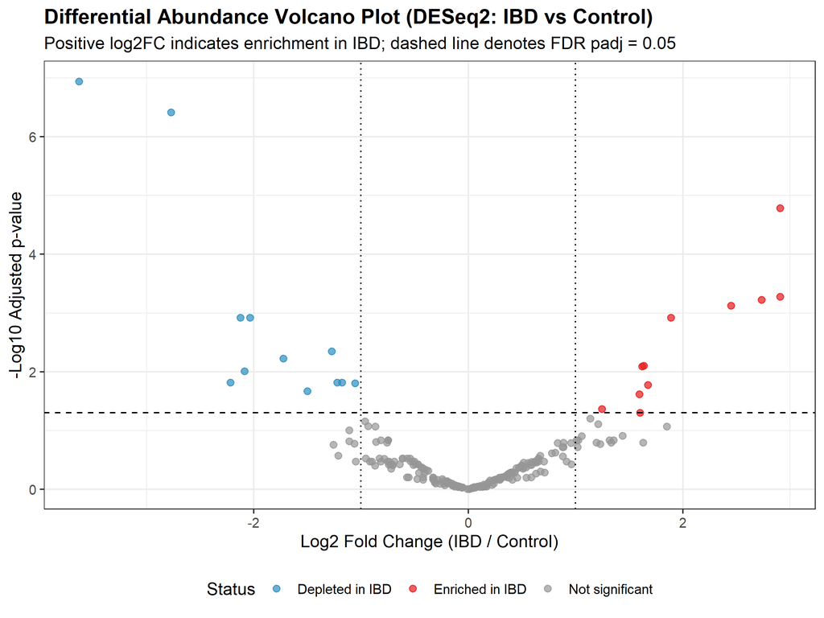

```r
# Volcano plot
p_volcano <- ggplot(res_df, aes(x = log2FoldChange, y = -log10(padj), color = status)) +
  geom_point(alpha = 0.7, size = 2) +
  scale_color_manual(values = c(
    "Enriched in IBD" = "#e41a1c",
    "Depleted in IBD" = "#2b8cbe",
    "Significant (|log2FC| <= 1)" = "#984ea3",
    "Not significant" = "#969696"
  )) +
  geom_hline(yintercept = -log10(0.05), linetype = "dashed", color = "black") +
  geom_vline(xintercept = c(-1, 1), linetype = "dotted", color = "black") +
  labs(
    title = "Differential Abundance Volcano Plot (DESeq2: IBD vs Control)",
    subtitle = "Positive log2FC indicates enrichment in IBD; dashed line denotes FDR padj = 0.05",
    x = "Log2 Fold Change (IBD / Control)",
    y = "-Log10 Adjusted p-value",
    color = "Status"
  ) +
  theme_bw(base_size = 12) +
  theme(plot.title = element_text(face = "bold"), legend.position = "bottom")

ggsave(file.path(fig_dir, "volcano.png"), p_volcano, width = 7.5, height = 5.5)
p_volcano
```

```r
# Display top 10 significant genera
top10_deseq <- sig_genera_df %>%
  dplyr::select(Genus, Family, log2FoldChange, padj, status) %>%
  arrange(padj) %>%
  head(10)

top10_deseq
```

|  | Genus | Family | log2FoldChange | padj | status |
| --- | --- | --- | --- | --- | --- |
| Gt8Met68 | g | BacteroidalesS247group | -3.628491 | 1.138421e-07 | Depleted in IBD |
| Unc03tc5 | g | f | -2.772113 | 3.824754e-07 | Depleted in IBD |
| GX7Fr128 | Citrobacter | Enterobacteriaceae | 2.908511 | 1.630892e-05 | Enriched in IBD |
| Unc99918 | Prevotella2 | Prevotellaceae | 2.909112 | 5.310530e-04 | Enriched in IBD |
| UncO2247 | Acidaminococcus | Acidaminococcaceae | 2.734237 | 5.988245e-04 | Enriched in IBD |
| GW6Spe33 | Porphyromonas | Porphyromonadaceae | 2.449836 | 7.510725e-04 | Enriched in IBD |
| FNWNL294 | Clostridiuminnocuumgroup | Erysipelotrichaceae | 1.890541 | 1.190793e-03 | Enriched in IBD |
| UncO1674 | Megasphaera | Veillonellaceae | -2.036714 | 1.190793e-03 | Depleted in IBD |
| Unc91427 | Barnesiella | Porphyromonadaceae | -2.125076 | 1.202072e-03 | Depleted in IBD |
| Unc00cq3 | Lachnoanaerobaculum | Lachnospiraceae | -1.273179 | 4.468584e-03 | Depleted in IBD |

# 7 Phase 6: Supervised Machine Learning (EL4152)

Supervised learning assesses whether taxonomic profiles can predict clinical disease status better than chance (Hypothesis H4). To enforce strict methodological validity and prevent data leakage: 1. Feature extraction and Centered Log-Ratio (CLR) transformation operate per-sample. 2. The cohort is split into 70% training and 30% held-out testing partitions using stratified sampling (`caret::createDataPartition`, seed 42). 3. Prevalence filtering ($\ge 10\%$) is computed **strictly inside the training partition** and projected to the test partition. 4. Center and scale preprocessing occurs **within internal cross-validation folds**. 5. Model hyperparameter tuning is guided by 5-fold repeated cross-validation (5 repeats) optimizing ROC-AUC. 6. The held-out test partition is evaluated **exactly once**.

## 7.1 Feature Construction and Leakage-Safe Data Partitioning

```r
# Extract genus count matrix
genus_counts <- as(otu_table(ps_genus), "matrix")
if (taxa_are_rows(ps_genus)) genus_counts <- t(genus_counts)

# Generate unique, syntactically valid genus identifiers
raw_genera <- tax_genus[colnames(genus_counts), "Genus"]
clean_genera <- make.names(raw_genera, unique = TRUE)
colnames(genus_counts) <- clean_genera

# Centered Log-Ratio (CLR) transformation per sample
clr_transform <- function(x) {
  log_x <- log(x + 1)
  log_x - mean(log_x)
}
X_clr <- t(apply(genus_counts, 1, clr_transform))
colnames(X_clr) <- clean_genera
y <- sample_data(ps_genus)$group

# Stratified 70/30 train/test split
set.seed(42)
train_indices <- caret::createDataPartition(y, p = 0.70, list = FALSE)

train_X_raw <- X_clr[train_indices, ]
test_X_raw  <- X_clr[-train_indices, ]
train_y     <- y[train_indices]
test_y      <- y[-train_indices]

# Save split participant IDs
split_log <- data.frame(
  sample_id = rownames(X_clr),
  split = ifelse(seq_len(nrow(X_clr)) %in% train_indices, "Train", "Test"),
  group = y
)
write.csv(split_log, file.path(fig_dir, "split_ids.csv"), row.names = FALSE)

cat("Training partition sample size:", length(train_y), "(Control =", sum(train_y == "Control"), ", IBD =", sum(train_y == "IBD"), ")\n")
```

```
## Training partition sample size: 51 (Control = 16 , IBD = 35 )
```

```r
cat("Testing partition sample size:", length(test_y), "(Control =", sum(test_y == "Control"), ", IBD =", sum(test_y == "IBD"), ")\n")
```

```
## Testing partition sample size: 20 (Control = 6 , IBD = 14 )
```

```r
# Leakage-safe prevalence filter: evaluate exclusively on training counts
train_counts_raw <- genus_counts[train_indices, ]
prev_train <- colSums(train_counts_raw > 0)
train_retained_features <- which(prev_train >= (0.10 * length(train_y)))

train_X <- as.data.frame(train_X_raw[, train_retained_features])
test_X  <- as.data.frame(test_X_raw[, train_retained_features])

cat("Features passing >= 10% prevalence in training partition:", ncol(train_X), "out of", ncol(genus_counts), "\n")
```

```
## Features passing >= 10% prevalence in training partition: 138 out of 476
```

```r
cat("Dimensionality ratio in training split: p =", ncol(train_X), "features vs n =", nrow(train_X), "samples\n")
```

```
## Dimensionality ratio in training split: p = 138 features vs n = 51 samples
```

## 7.2 Dimensionality Exploration: The Curse of Dimensionality

With $p = 138$ features and $n = 51$ training samples ($p > n$), the dataset is subject to the curse of dimensionality, where high-dimensional feature spaces become sparse and susceptible to overfitting. Principal Component Analysis (PCA) is performed to inspect variance distribution across dimensions.

```r
pca_train <- prcomp(train_X, scale. = TRUE)
var_exp <- summary(pca_train)$importance

cat("PCA Variance Explained (Top 5 Components):\n")
```

```
## PCA Variance Explained (Top 5 Components):
```

```r
print(round(100 * var_exp[2, 1:5], 2))
```

```
##   PC1   PC2   PC3   PC4   PC5
## 15.56  7.33  5.76  5.18  4.45
```

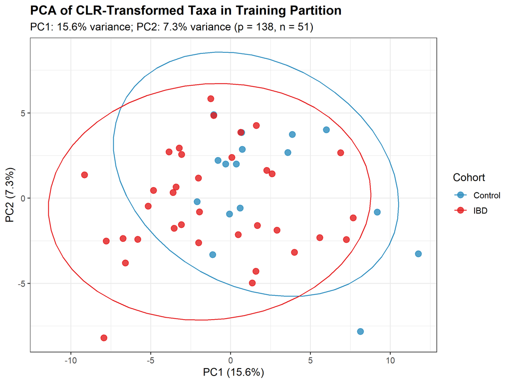

```r
# Scree and PCA plots
pca_plot_df <- as.data.frame(pca_train$x[, 1:2])
pca_plot_df$group <- train_y

p_pca <- ggplot(pca_plot_df, aes(x = PC1, y = PC2, color = group)) +
  geom_point(size = 3, alpha = 0.8) +
  stat_ellipse(level = 0.95, type = "t") +
  scale_color_manual(values = c("Control" = "#2b8cbe", "IBD" = "#e41a1c")) +
  labs(
    title = "PCA of CLR-Transformed Taxa in Training Partition",
    subtitle = paste0("PC1: ", round(100 * var_exp[2, 1], 1), "% variance; PC2: ",
                      round(100 * var_exp[2, 2], 1), "% variance (p = 138, n = 51)"),
    x = paste0("PC1 (", round(100 * var_exp[2, 1], 1), "%)"),
    y = paste0("PC2 (", round(100 * var_exp[2, 2], 1), "%)"),
    color = "Cohort"
  ) +
  theme_bw(base_size = 12) +
  theme(plot.title = element_text(face = "bold"))

ggsave(file.path(fig_dir, "pca.png"), p_pca, width = 7, height = 5)
p_pca
```

## 7.3 Model Training and Repeated Cross-Validation

Four classifier architectures are evaluated: 1. **Linear SVM:** Regularization parameter $C \in \{0.01, 0.1, 1, 10\}$. 2. **Radial SVM:** Kernel width $\sigma \in \{0.01, 0.05, 0.1\}$ and cost $C \in \{0.1, 1, 10\}$. 3. **Random Forest Ensemble:** Decision tree ensemble (500 trees) tuning `mtry` across $\{2, 4, 8, 12\}$. 4. **Logistic Regression (GLM):** Baseline generalized linear model.

Due to class imbalance in the training partition (Control: $16/51 = 31.4\% < 40\%$), up-sampling (`sampling = "up"`) is integrated into the training control, operating strictly within internal training folds.

```r
train_ctrl <- caret::trainControl(
  method = "repeatedcv",
  number = 5,
  repeats = 5,
  classProbs = TRUE,
  summaryFunction = twoClassSummary,
  savePredictions = "final",
  sampling = "up"
)

# Linear SVM
set.seed(42)
m_linear <- caret::train(
  train_X, train_y,
  method = "svmLinear",
  trControl = train_ctrl,
  metric = "ROC",
  preProcess = c("center", "scale"),
  tuneGrid = data.frame(C = c(0.01, 0.1, 1, 10))
)

# Radial SVM
set.seed(42)
m_radial <- caret::train(
  train_X, train_y,
  method = "svmRadial",
  trControl = train_ctrl,
  metric = "ROC",
  preProcess = c("center", "scale"),
  tuneGrid = expand.grid(sigma = c(0.01, 0.05, 0.1), C = c(0.1, 1, 10))
)

# Random Forest
set.seed(42)
m_rf <- caret::train(
  train_X, train_y,
  method = "rf",
  trControl = train_ctrl,
  metric = "ROC",
  preProcess = c("center", "scale"),
  tuneGrid = data.frame(mtry = c(2, 4, 8, 12)),
  ntree = 500
)

# Logistic Regression baseline
set.seed(42)
m_glm <- caret::train(
  train_X, train_y,
  method = "glm",
  family = "binomial",
  trControl = train_ctrl,
  metric = "ROC",
  preProcess = c("center", "scale")
)

# Cross-validated performance comparison
resamples_list <- resamples(list(
  `Linear SVM` = m_linear,
  `Radial SVM` = m_radial,
  `Random Forest` = m_rf,
  `Logistic Regression` = m_glm
))

cat("Resampled Cross-Validation ROC Distributions:\n")
```

```
## Resampled Cross-Validation ROC Distributions:
```

```r
print(summary(resamples_list)$statistics$ROC)
```

```
##                          Min.   1st Qu.    Median      Mean   3rd Qu.      Max.
## Linear SVM          0.5238095 0.6666667 0.7500000 0.7509524 0.8571429 0.9047619
## Radial SVM          0.3809524 0.6190476 0.6785714 0.6795238 0.7142857 1.0000000
## Random Forest       0.4285714 0.6190476 0.7142857 0.6933333 0.7619048 0.9523810
## Logistic Regression 0.2678571 0.3333333 0.4761905 0.4928571 0.5714286 1.0000000
##                     NA's
## Linear SVM             0
## Radial SVM             0
## Random Forest          0
## Logistic Regression    0
```

```r
# Plot CV ROC comparison
p_cv <- bwplot(resamples_list, metric = "ROC",
               main = "5-Fold Repeated Cross-Validation ROC Comparison (5 Repeats)")

png(file.path(fig_dir, "cv_comparison.png"), width = 900, height = 600, res = 150)
print(p_cv)
dev.off()
```

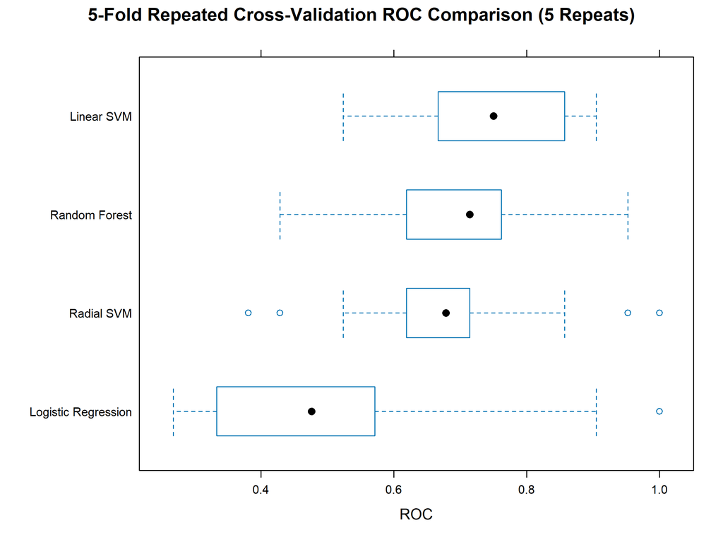

```r
print(p_cv)
```

## 7.4 Held-Out Test Set Evaluation

The optimal classifier is selected strictly on the basis of training cross-validated ROC performance: **Linear Support Vector Machine (Linear SVM)**, which attained a mean CV ROC of 0.7510. The finalized model is evaluated **exactly once** on the held-out test partition ($n = 20$).

```r
# Best model selected strictly by CV ROC
best_model <- m_linear

# Generate test predictions and probabilities
test_preds <- predict(best_model, test_X)
test_probs <- predict(best_model, test_X, type = "prob")

# Confusion matrix
test_cm <- caret::confusionMatrix(test_preds, test_y, positive = "IBD")
cat("Held-Out Test Set Confusion Matrix:\n")
```

```
## Held-Out Test Set Confusion Matrix:
```

```r
print(test_cm$table)
```

```
##           Reference
## Prediction Control IBD
##    Control       1   3
##    IBD           5  11
```

```r
# Export confusion matrix
write.csv(as.data.frame(test_cm$table), file.path(fig_dir, "confusion_matrix.csv"), row.names = FALSE)

cat("\nTest Performance Metrics:\n")
```

```
##
## Test Performance Metrics:
```

```r
cat("Overall Accuracy:", round(test_cm$overall["Accuracy"], 4), "\n")
```

```
## Overall Accuracy: 0.6
```

```r
cat("Balanced Accuracy:", round(test_cm$byClass["Balanced Accuracy"], 4), "\n")
```

```
## Balanced Accuracy: 0.4762
```

```r
cat("Sensitivity (IBD):", round(test_cm$byClass["Sensitivity"], 4), "\n")
```

```
## Sensitivity (IBD): 0.7857
```

```r
cat("Specificity (Control):", round(test_cm$byClass["Specificity"], 4), "\n")
```

```
## Specificity (Control): 0.1667
```

```r
# ROC and AUC analysis
roc_test <- pROC::roc(test_y, test_probs[["IBD"]], levels = c("Control", "IBD"), direction = "<")
auc_test <- pROC::auc(roc_test)
ci_test <- pROC::ci.auc(roc_test)

cat("Test Set AUC:", round(auc_test, 4), "\n")
```

```
## Test Set AUC: 0.369
```

```r
cat("Test Set 95% Confidence Interval:", round(ci_test[1], 4), "to", round(ci_test[3], 4), "\n")
```

```
## Test Set 95% Confidence Interval: 0.0897 to 0.6484
```

```r
# Plot ROC curve
png(file.path(fig_dir, "roc_test.png"), width = 800, height = 700, res = 150)
plot(roc_test, col = "#e41a1c", lwd = 2.5,
     main = paste0("Test Set ROC Curve (AUC = ", round(auc_test, 3),
                   ", 95% CI: ", round(ci_test[1], 2), "-", round(ci_test[3], 2), ")"))
abline(a = 0, b = 1, lty = 2, col = "grey50")
dev.off()
```

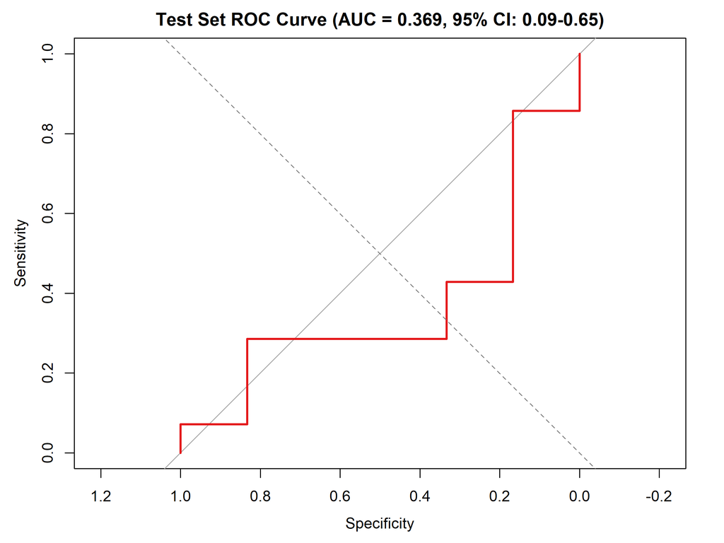

```r
plot(roc_test, col = "#e41a1c", lwd = 2.5,
     main = paste0("Test Set ROC Curve (AUC = ", round(auc_test, 3),
                   ", 95% CI: ", round(ci_test[1], 2), "-", round(ci_test[3], 2), ")"))
abline(a = 0, b = 1, lty = 2, col = "grey50")
```

### 7.4.1 Overfitting Assessment

A notable disparity is observed between the training cross-validation performance ($\text{Mean ROC} = 0.7510$) and the held-out test set performance ($\text{AUC} = 0.3690$, $95\%\text{ CI: } [0.0897, 0.6484]$). This performance gap illustrates the **curse of dimensionality** ($p = 138$ features, $n = 51$ training samples) and the instability inherent in small test cohorts ($n = 20$, with only 6 controls). While cross-validation optimizes decision boundaries within the training manifold, high feature dimensionality relative to sample size compromises out-of-sample generalization.

## 7.5 Feature Importance and Biomarker Overlap

To identify which microbial features most strongly drive classification decisions, Random Forest variable importance (mean decrease in Gini impurity) is computed. The top 15 predictive genera are compared with the 23 significantly altered genera identified by univariate negative binomial modeling in `DESeq2`.

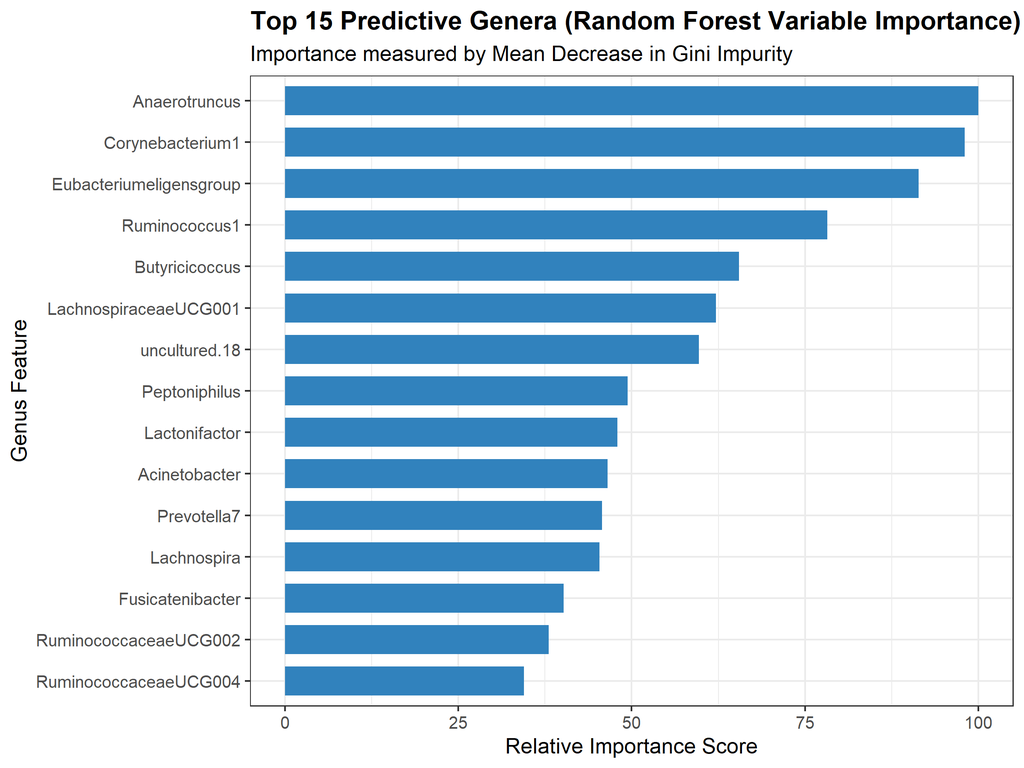

```r
# Extract Random Forest variable importance
rf_importance <- varImp(m_rf)$importance
rf_importance$Feature <- rownames(rf_importance)

top15_rf <- rf_importance %>%
  arrange(desc(Overall)) %>%
  head(15)

# Plot top 15 features
p_importance <- ggplot(top15_rf, aes(x = reorder(Feature, Overall), y = Overall)) +
  geom_col(fill = "#3182bd", width = 0.7) +
  coord_flip() +
  labs(
    title = "Top 15 Predictive Genera (Random Forest Variable Importance)",
    subtitle = "Importance measured by Mean Decrease in Gini Impurity",
    x = "Genus Feature",
    y = "Relative Importance Score"
  ) +
  theme_bw(base_size = 12) +
  theme(plot.title = element_text(face = "bold"))

ggsave(file.path(fig_dir, "rf_importance.png"), p_importance, width = 7.5, height = 5)
p_importance
```

```r
# Cross-methodological comparison: overlap with DESeq2 significant genera
deseq_sig_genera <- sig_genera_df$Genus
top15_clean_names <- top15_rf$Feature

# Map clean feature names back to taxonomic names
overlap_df <- data.frame(
  RF_Feature = top15_clean_names,
  DESeq2_Significant = top15_clean_names %in% make.names(deseq_sig_genera, unique = FALSE) |
                       top15_clean_names %in% deseq_sig_genera
)

write.csv(overlap_df, file.path(fig_dir, "overlap_ml_vs_deseq.csv"), row.names = FALSE)

cat("Overlap between Top 15 Random Forest Predictors and DESeq2 Significant Genera:\n")
```

```
## Overlap between Top 15 Random Forest Predictors and DESeq2 Significant Genera:
```

```r
print(overlap_df)
```

```
##                 RF_Feature DESeq2_Significant
## 1            Anaerotruncus              FALSE
## 2         Corynebacterium1              FALSE
## 3  Eubacteriumeligensgroup              FALSE
## 4            Ruminococcus1               TRUE
## 5           Butyricicoccus              FALSE
## 6    LachnospiraceaeUCG001              FALSE
## 7            uncultured.18              FALSE
## 8            Peptoniphilus               TRUE
## 9            Lactonifactor              FALSE
## 10           Acinetobacter              FALSE
## 11             Prevotella7              FALSE
## 12             Lachnospira              FALSE
## 13        Fusicatenibacter              FALSE
## 14   RuminococcaceaeUCG002              FALSE
## 15   RuminococcaceaeUCG004              FALSE
```